# Exlporation on Indeed

Haoyu Wang

12/13/2020

# Introduction

We may face obstacles finding jobs. I guess most of us want to find jobs associated with data analysis. For me, I may find a job as a data analyst or a data scientist. However, for now I have no idea about how to find it. Then I searched on Indeed, trying to find something that will be helpful. I mainly focused on the information in job description, trying to give some analysis.

# About the data set

Indeed has a straight-forward structure, which is very easy to search a job. Here is the link and preview of the wibset:

https://www.indeed.com/jobs?q=data+scientist&l=all&start=

[figure not shown]

We can just do a simple scrape with *rvest* library in R. For the convience, I stored data into a csv file for further step.

The next step is data cleaning. I removed stopwords, punctuation, and numbers, and converted it to lowercase.

# Exploratory Data Analysis

## Working experience

Here is a quesiton:

> *How many years of working experience do those companies ask for?*

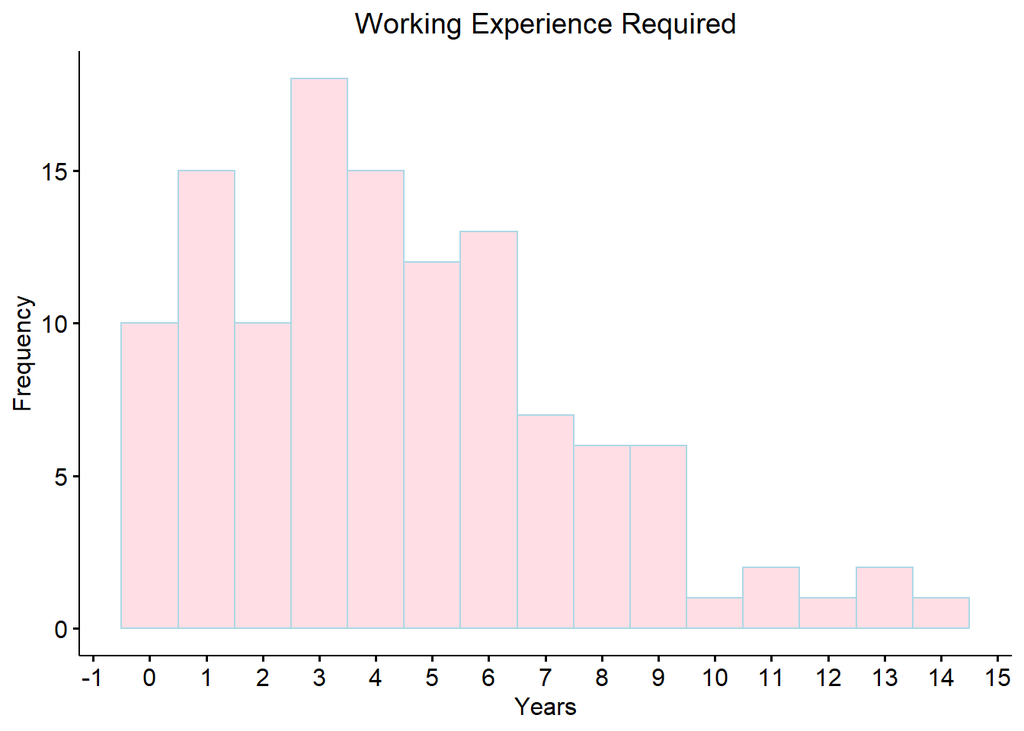

## Most frequent words

Now, let’s see the top 10 most frequent words from November Data Set:

| word | n |
| --- | --- |
| data | 1371 |
| experience | 539 |
| science | 337 |
| business | 322 |
| learning | 300 |
| team | 292 |
| machine | 226 |
| analysis | 217 |
| analytics | 208 |
| skills | 208 |

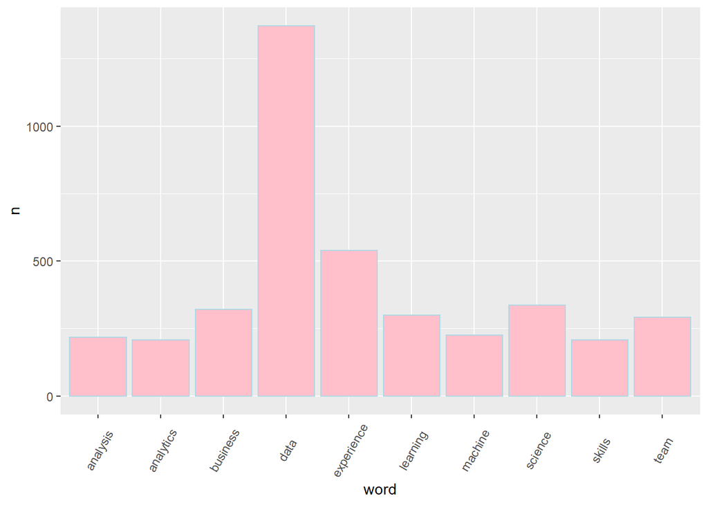

The word “data” is the most frequent with no doubt. “experience” follows by, which indicates that working experience is important in this position. Another observation is *“machine learning”*. We can conclude that for data scientists, machine learning is also a core skill.

## Companies and Locations

Let’s look at Companies and locations.

| company | n |
| --- | --- |
| CVS Health | 1601 |
| Analysis Group, Inc. | 1285 |
| Facebook | 1044 |
| Microsoft | 881 |
| World Bank Group | 821 |
| Getty Images | 664 |
| Liberty Mutual Insurance | 610 |
| Mayo Clinic | 600 |
| FedEx Services | 573 |
| ORTEC | 531 |

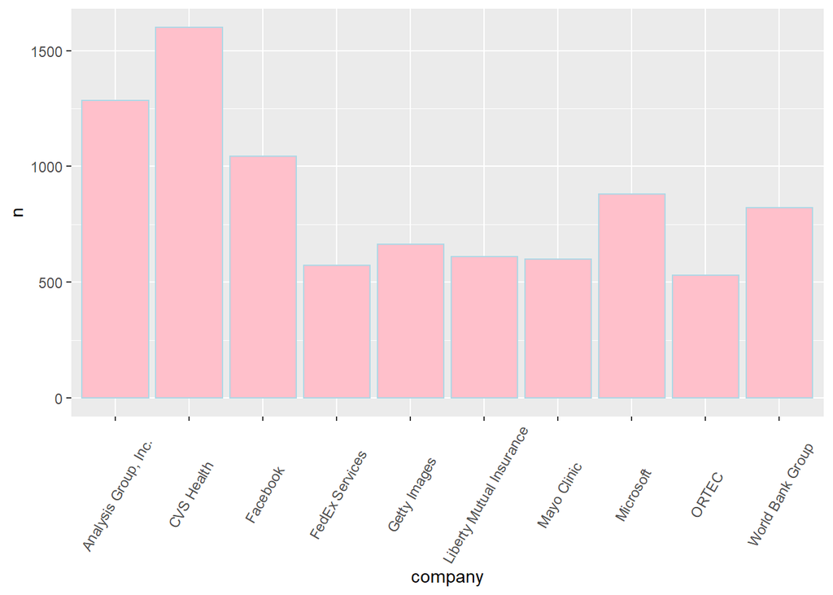

| location | n |
| --- | --- |
| Boston, MA | 5924 |
| NA | 5609 |
| New York, NY | 4144 |
| Cambridge, MA | 2828 |
| Wellesley, MA | 1290 |
| San Francisco, CA | 1275 |
| Chicago, IL | 1264 |
| Washington, DC | 971 |
| Somerville, MA | 902 |
| Palo Alto, CA | 757 |

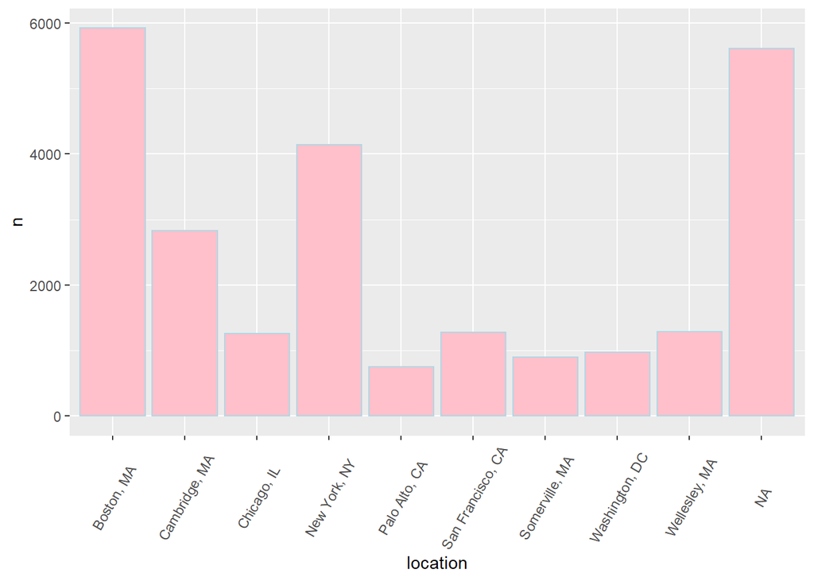

# Words Cloud

This is the funny part that I want to try. All the words can be visualized by using *wordcloud2* package in R.

[interactive chart not shown]

# Summary and Conclusion

> *What can we get from the visualization?*
- A data scientist positon usually needs people who have 3-6 year experience;
- Not only technique companies need data scientists, so don’t find job only in this field;
- Boston and New York may have more chance.
- As a scientist, modeling and machine learning are important.
- Personally speaking, after graduation I would recommend us starting as data analyst.